# GLM_Project

Hamed Helali

3/20/2020

## Introduction

Since acquiring a new customer is far more expensive than retaining an existing one, customers’ exit is a seriously undesirable customer behavior that banks (like many other businesses) try to prevent. In this regard, developing a model that can predict a customer’s exit comes to a great importance. Using such model, banks can predict exit of their valuable customers and take measures to prevent that. In this project, we develop a classification model (based on logistic regression) to predict churn behavior of customers of a hypothetical bank.

```r
### loading libraries
library(readr)
library(knitr)
library(caret)
library(e1071)
library(generalhoslem)
library(scales)
library(ggplot2)
library(psych)
library(corrplot)
library(table1)
```

## Prepairing data and some exploratory analysis

The data set for this project is selected from Kaggle. This data set consists of different features of about 10000 customers of a bank and the target variable is a binary variable reflecting the fact whether the customer left the bank (closed his account) or he continues to be a customer.

```r
Churn_Data <- read_csv("/Users/hamed/Documents/Academics/Generalized Linear Models/Term Project/Churn_Modelling.csv")
# Excluding columns of id and name
Churn_Data <- subset(Churn_Data,select = 4:ncol(Churn_Data))

Churn_Data$Exited <- as.factor(Churn_Data$Exited)
```

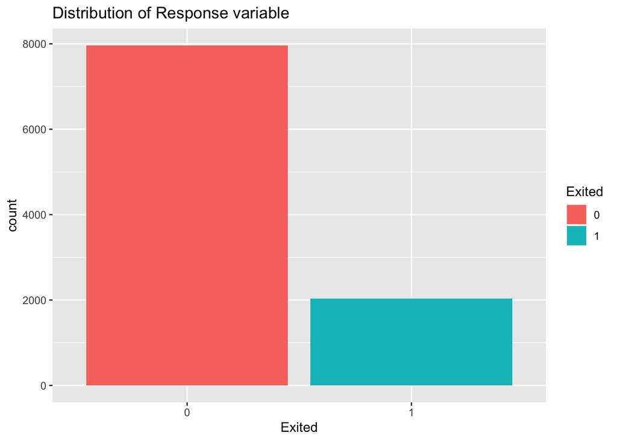

```r
## For Distribution of Response Variable
ggplot2::ggplot(Churn_Data,aes(Exited,fill =Exited))+geom_bar() + ggtitle("Distribution of Response variable")
```

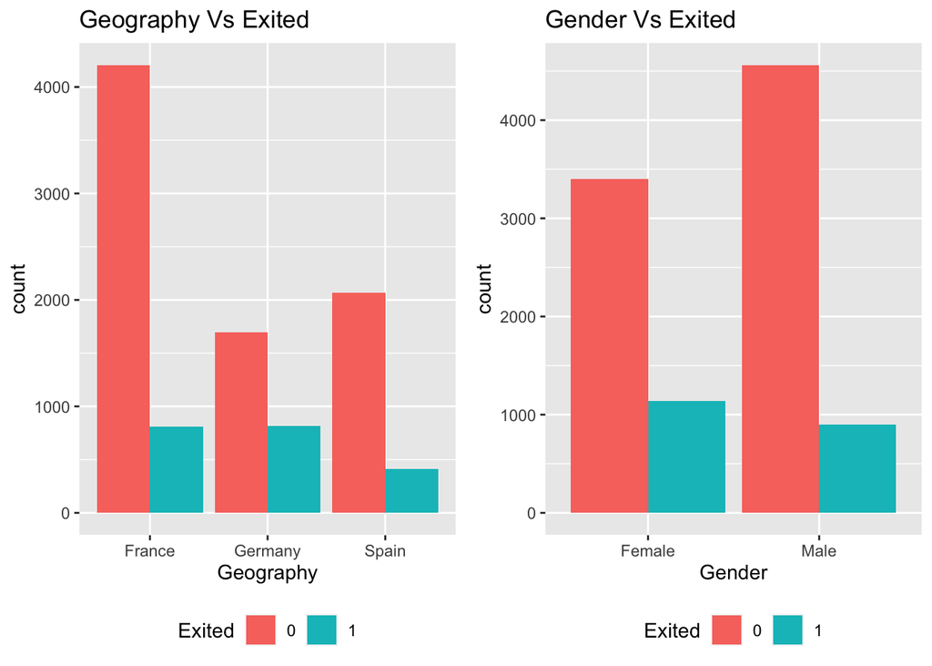

```r
## For categorical Predictor Variables
# Geography
p1=ggplot2::ggplot(Churn_Data,aes(x =Geography ,fill = Exited)) +
geom_bar(position = "Dodge") +
theme(legend.position = "bottom") +labs(title = "Geography Vs Exited")

# Gender
p2=ggplot2::ggplot(Churn_Data,aes(x = Gender ,fill = Exited)) + geom_bar(position = "Dodge") +
theme(legend.position = "bottom") + labs(title = "Gender Vs Exited")
gridExtra::grid.arrange(p1, p2, ncol = 2)
```

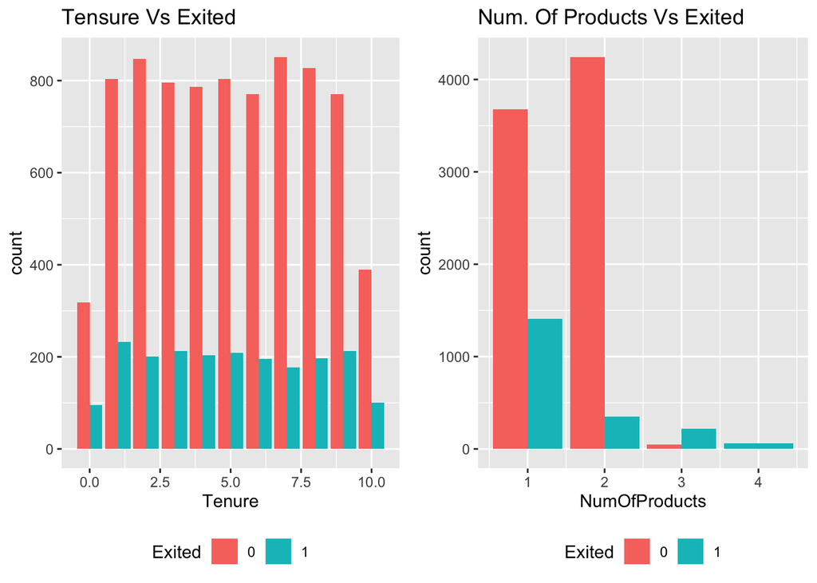

```r
# For Tenure
p1=ggplot2::ggplot(Churn_Data,aes(x = Tenure ,fill = Exited)) + geom_bar(position = "Dodge") +
theme(legend.position = "bottom") + labs(title = "Tensure Vs Exited")

# For Number of Products
p2=ggplot2::ggplot(Churn_Data,aes(x = NumOfProducts ,fill = Exited)) + geom_bar(position = "Dodge") +
theme(legend.position = "bottom") + labs(title = "Num. Of Products Vs Exited")
gridExtra::grid.arrange(p1, p2, ncol = 2)
```

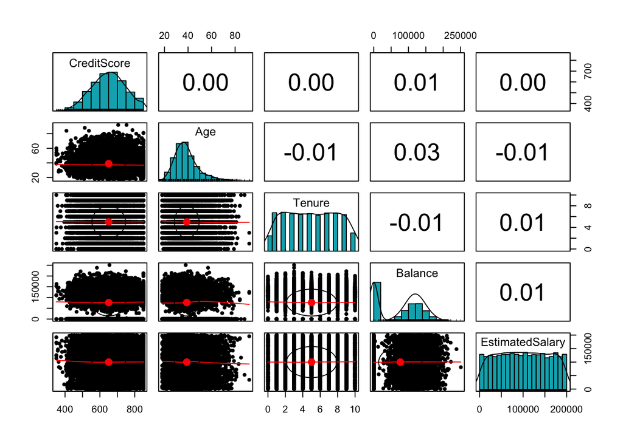

```r
# Examining multi-collinearity between continuous independant variables.
con_var <- subset(Churn_Data, select = c("CreditScore","Age","Tenure","Balance","EstimatedSalary"))
psych::pairs.panels(con_var,
             method = "pearson", # correlation method
             hist.col = "#00AFBB",
             density = TRUE,  # show density plots
             ellipses = TRUE # show correlation ellipses
             )
```

```r
kable(cor(con_var))
```

|  | CreditScore | Age | Tenure | Balance | EstimatedSalary |
| --- | --- | --- | --- | --- | --- |
| CreditScore | 1.0000000 | -0.0039649 | 0.0008419 | 0.0062684 | -0.0013843 |
| Age | -0.0039649 | 1.0000000 | -0.0099968 | 0.0283084 | -0.0072010 |
| Tenure | 0.0008419 | -0.0099968 | 1.0000000 | -0.0122539 | 0.0077838 |
| Balance | 0.0062684 | 0.0283084 | -0.0122539 | 1.0000000 | 0.0127975 |
| EstimatedSalary | -0.0013843 | -0.0072010 | 0.0077838 | 0.0127975 | 1.0000000 |

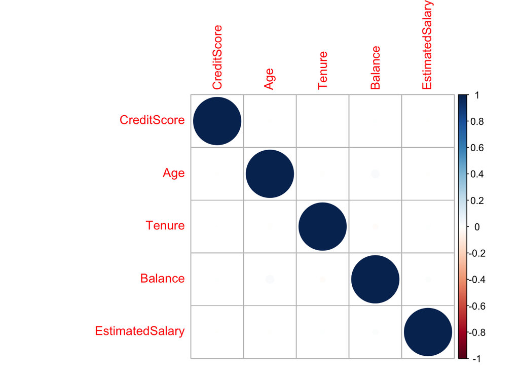

```r
cr=cor(con_var,method=c("pearson"))
## For Correaltion Plot
corrplot::corrplot(cr,method="circle")
```

There is no multi-collinearity problem. correlations are not extreme and basically as long as our objective is prediction, multi-collinearity is not a concern. Because even in extreme case of correlation between independant variables, coefficients’ estimates are still unbiased.

## Spliting dataset to train and test segments

```r
set.seed(648)
ind <- sample(2, nrow(Churn_Data), replace = TRUE, prob = c(0.8, 0.2))
train_data <- Churn_Data[ind==1,]
test_data <- Churn_Data[ind==2,]

#Check proportion of churned and unchurned users in train and test data
df1 <- data.frame(
  "Chruned Customers" = c(sum(train_data$Exited == 1),sum(test_data$Exited == 1)),
  "Chruned Proportion" = c(percent(sum(train_data$Exited == 1) / nrow(train_data)), percent(sum(test_data$Exited == 1) / nrow(test_data))),
  "Not-churned Customers" = c(sum(train_data$Exited == 0),sum(test_data$Exited == 0)),
  "Not-chruned Proportion" = c(percent(sum(train_data$Exited == 0) / nrow(train_data)), percent(sum(test_data$Exited == 0) / nrow(test_data)))
)
row.names(df1) <- c("Train data", "Test data")
kable(df1, align = 'r',caption = "Proportion of Churned Customers in training and test datasets")
```

Proportion of Churned Customers in training and test datasets

|  | Chruned.Customers | Chruned.Proportion | Not.churned.Customers | Not.chruned.Proportion |
| --- | --- | --- | --- | --- |
| Train data | 1665 | 21% | 6342 | 79% |
| Test data | 372 | 19% | 1621 | 81% |

## Choosing link function

```r
#### MODEL 1
model1 <- glm(Exited ~., family = binomial(), data = train_data)
summary(model1)
```

```
##
## Call:
## glm(formula = Exited ~ ., family = binomial(), data = train_data)
##
## Deviance Residuals:
##     Min       1Q   Median       3Q      Max
## -2.3013  -0.6670  -0.4632  -0.2745   2.9528
##
## Coefficients:
##                    Estimate Std. Error z value Pr(>|z|)
## (Intercept)      -3.391e+00  2.720e-01 -12.465  < 2e-16 ***
## CreditScore      -4.582e-04  3.107e-04  -1.475   0.1402
## GeographyGermany  7.305e-01  7.527e-02   9.706  < 2e-16 ***
## GeographySpain   -2.749e-02  7.821e-02  -0.351   0.7252
## GenderMale       -5.216e-01  6.034e-02  -8.644  < 2e-16 ***
## Age               7.157e-02  2.827e-03  25.315  < 2e-16 ***
## Tenure           -1.551e-02  1.037e-02  -1.497   0.1345
## Balance           2.376e-06  5.682e-07   4.182 2.89e-05 ***
## NumOfProducts    -1.228e-01  5.258e-02  -2.336   0.0195 *
## HasCrCard        -4.335e-02  6.590e-02  -0.658   0.5107
## IsActiveMember   -1.042e+00  6.366e-02 -16.363  < 2e-16 ***
## EstimatedSalary   4.618e-07  5.245e-07   0.880   0.3786
## ---
## Signif. codes:  0 '***' 0.001 '**' 0.01 '*' 0.05 '.' 0.1 ' ' 1
##
## (Dispersion parameter for binomial family taken to be 1)
##
##     Null deviance: 8186.7  on 8006  degrees of freedom
## Residual deviance: 6965.1  on 7995  degrees of freedom
## AIC: 6989.1
##
## Number of Fisher Scoring iterations: 5
```

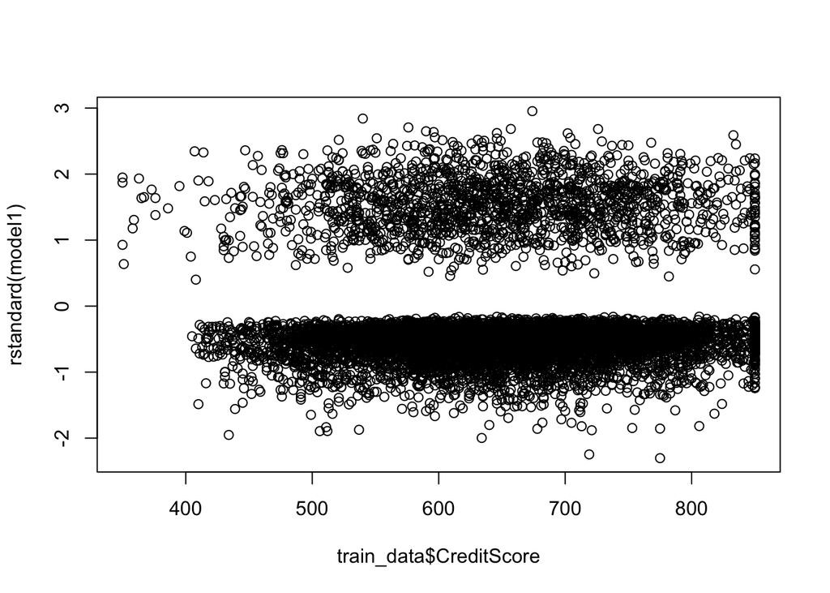

```r
#### Maybe we should drop this section too

#plot residuals against continuous explanatory variables
plot(train_data$CreditScore,rstandard(model1))
```

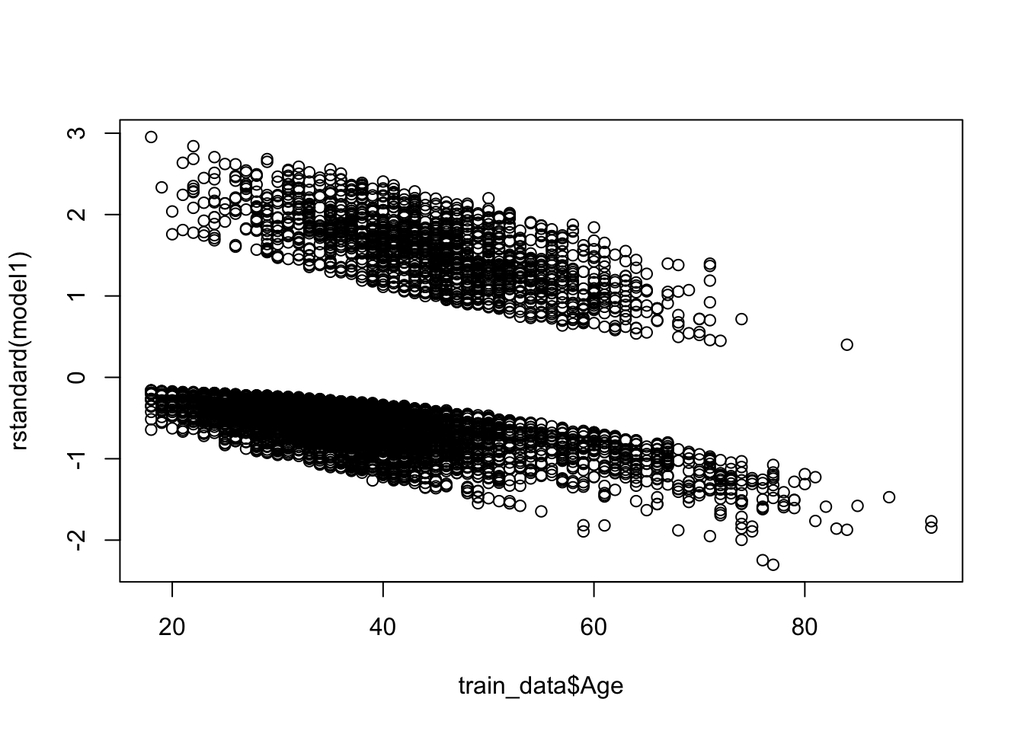

```r
plot(train_data$Age,rstandard(model1))
```

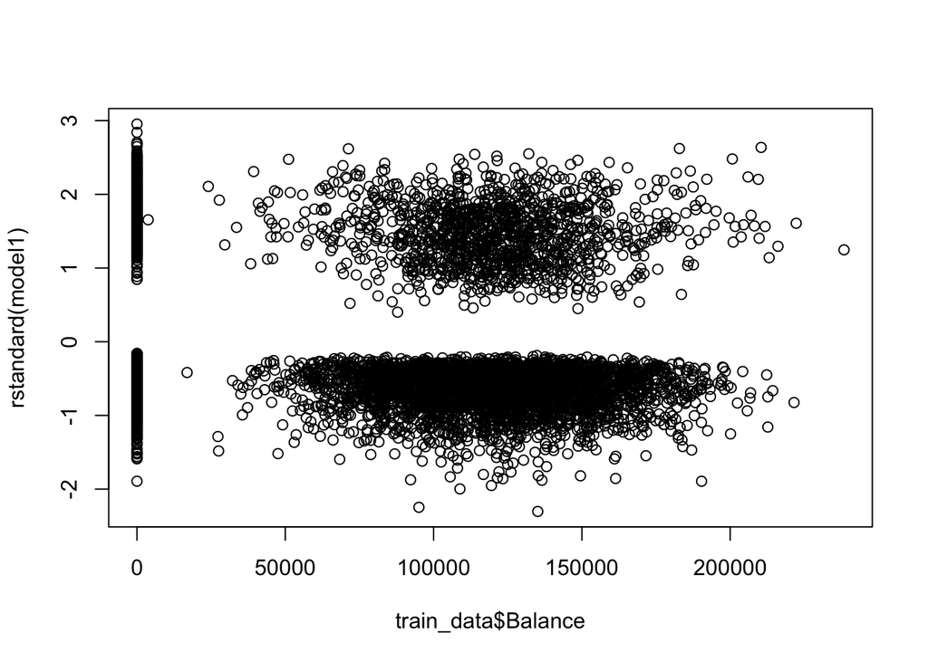

```r
plot(train_data$Balance,rstandard(model1))
```

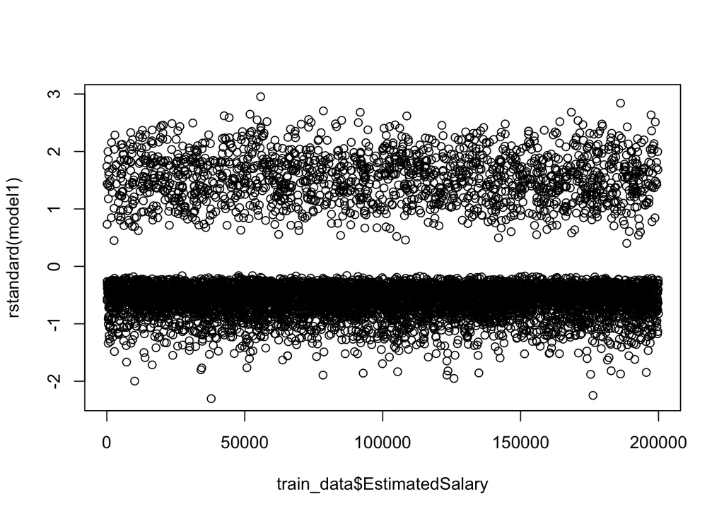

```r
plot(train_data$EstimatedSalary,rstandard(model1))
```

```r
### ModeL 1 - Probit link function
model1_prob <- glm(Exited ~., family = binomial(link = "probit"), data = train_data)
summary(model1_prob)
```

```
##
## Call:
## glm(formula = Exited ~ ., family = binomial(link = "probit"),
##     data = train_data)
##
## Deviance Residuals:
##     Min       1Q   Median       3Q      Max
## -2.2781  -0.6772  -0.4654  -0.2482   3.1883
##
## Coefficients:
##                    Estimate Std. Error z value Pr(>|z|)
## (Intercept)      -1.985e+00  1.542e-01 -12.871  < 2e-16 ***
## CreditScore      -2.930e-04  1.764e-04  -1.661   0.0967 .
## GeographyGermany  4.195e-01  4.338e-02   9.669  < 2e-16 ***
## GeographySpain   -1.323e-02  4.357e-02  -0.304   0.7614
## GenderMale       -3.010e-01  3.419e-02  -8.803  < 2e-16 ***
## Age               4.127e-02  1.603e-03  25.744  < 2e-16 ***
## Tenure           -8.475e-03  5.893e-03  -1.438   0.1504
## Balance           1.377e-06  3.199e-07   4.305 1.67e-05 ***
## NumOfProducts    -6.239e-02  3.015e-02  -2.069   0.0385 *
## HasCrCard        -2.605e-02  3.741e-02  -0.696   0.4862
## IsActiveMember   -5.641e-01  3.525e-02 -16.004  < 2e-16 ***
## EstimatedSalary   2.637e-07  2.977e-07   0.886   0.3758
## ---
## Signif. codes:  0 '***' 0.001 '**' 0.01 '*' 0.05 '.' 0.1 ' ' 1
##
## (Dispersion parameter for binomial family taken to be 1)
##
##     Null deviance: 8186.7  on 8006  degrees of freedom
## Residual deviance: 6966.6  on 7995  degrees of freedom
## AIC: 6990.6
##
## Number of Fisher Scoring iterations: 5
```

```r
### ModeL 1 - Cloglog link function
model1_cloglog <- glm(Exited ~., family = binomial(link = "cloglog"), data = train_data)
summary(model1_cloglog)
```

```
##
## Call:
## glm(formula = Exited ~ ., family = binomial(link = "cloglog"),
##     data = train_data)
##
## Deviance Residuals:
##     Min       1Q   Median       3Q      Max
## -3.1631  -0.6637  -0.4759  -0.3052   2.8081
##
## Coefficients:
##                    Estimate Std. Error z value Pr(>|z|)
## (Intercept)      -2.959e+00  2.234e-01 -13.243  < 2e-16 ***
## CreditScore      -3.753e-04  2.558e-04  -1.467   0.1423
## GeographyGermany  5.725e-01  6.129e-02   9.341  < 2e-16 ***
## GeographySpain   -2.076e-02  6.732e-02  -0.308   0.7578
## GenderMale       -4.230e-01  5.024e-02  -8.419  < 2e-16 ***
## Age               5.510e-02  2.166e-03  25.440  < 2e-16 ***
## Tenure           -1.433e-02  8.588e-03  -1.669   0.0951 .
## Balance           2.014e-06  4.817e-07   4.182 2.89e-05 ***
## NumOfProducts    -1.065e-01  4.328e-02  -2.462   0.0138 *
## HasCrCard        -4.797e-02  5.464e-02  -0.878   0.3800
## IsActiveMember   -9.478e-01  5.396e-02 -17.564  < 2e-16 ***
## EstimatedSalary   3.388e-07  4.338e-07   0.781   0.4348
## ---
## Signif. codes:  0 '***' 0.001 '**' 0.01 '*' 0.05 '.' 0.1 ' ' 1
##
## (Dispersion parameter for binomial family taken to be 1)
##
##     Null deviance: 8186.7  on 8006  degrees of freedom
## Residual deviance: 6989.8  on 7995  degrees of freedom
## AIC: 7013.8
##
## Number of Fisher Scoring iterations: 8
```

```r
df2 <- data.frame(
  "Deviance" = c(model1$deviance, model1_prob$deviance, model1_cloglog$deviance),
  "AIC" = c(model1$aic, model1_prob$aic, model1_cloglog$aic)
)
row.names(df2) <- c("Logit","Probit","Cloglog")
kable(df2)
```

|  | Deviance | AIC |
| --- | --- | --- |
| Logit | 6965.088 | 6989.088 |
| Probit | 6966.581 | 6990.581 |
| Cloglog | 6989.756 | 7013.756 |

Regarding deviance and AIC criteria (which are necessarily consistent) model with the logit link function fits the best and we proceed our analysis with logit link function.

## Suggesting a more parsimonious model

I am dropping insignificant independant variables to see if we can have more parsimonous model

```r
model2 <- glm(Exited ~.-CreditScore-Tenure-HasCrCard-EstimatedSalary, family = binomial(), data = train_data)
summary(model2)
```

```
##
## Call:
## glm(formula = Exited ~ . - CreditScore - Tenure - HasCrCard -
##     EstimatedSalary, family = binomial(), data = train_data)
##
## Deviance Residuals:
##     Min       1Q   Median       3Q      Max
## -2.3467  -0.6651  -0.4646  -0.2749   2.9265
##
## Coefficients:
##                    Estimate Std. Error z value Pr(>|z|)
## (Intercept)      -3.748e+00  1.609e-01 -23.290  < 2e-16 ***
## GeographyGermany  7.273e-01  7.519e-02   9.672  < 2e-16 ***
## GeographySpain   -2.850e-02  7.817e-02  -0.365   0.7154
## GenderMale       -5.230e-01  6.029e-02  -8.675  < 2e-16 ***
## Age               7.152e-02  2.825e-03  25.316  < 2e-16 ***
## Balance           2.394e-06  5.677e-07   4.217 2.48e-05 ***
## NumOfProducts    -1.226e-01  5.253e-02  -2.334   0.0196 *
## IsActiveMember   -1.040e+00  6.353e-02 -16.370  < 2e-16 ***
## ---
## Signif. codes:  0 '***' 0.001 '**' 0.01 '*' 0.05 '.' 0.1 ' ' 1
##
## (Dispersion parameter for binomial family taken to be 1)
##
##     Null deviance: 8186.7  on 8006  degrees of freedom
## Residual deviance: 6970.7  on 7999  degrees of freedom
## AIC: 6986.7
##
## Number of Fisher Scoring iterations: 5
```

```r
model2$deviance
```

```
## [1] 6970.709
```

```r
Dev_test <- abs(model2$deviance - model1$deviance) > qchisq(0.95,4)
Dev_test
```

```
## [1] FALSE
```

According to Deviance test, null hypothesis is not rejected and covariates in model 2 are enough to explain response variable.

## Hosmer-Lemeshow goodness-of-fit statistic

```r
hoslem <- logitgof(train_data$Exited, model2$fitted.values, g=10)
hoslem
```

```
##
##  Hosmer and Lemeshow test (binary model)
##
## data:  train_data$Exited, model2$fitted.values
## X-squared = 13.22, df = 8, p-value = 0.1045
```

we cannot reject null-hypothesis (goodness of fit of this model) in %95 significance level

## Confusion matrix and checking accuracy of models

### Model with all independant variables

```r
###accuracy of prediction for model 1

prediction1 <- predict(model1, test_data,type = "response")
threshold = 0.5
prediction1[prediction1 >= threshold] <- 1
prediction1[prediction1 < threshold] <- 0
confusionMatrix(as.factor(prediction1), test_data$Exited, positive = '1')
```

```
## Confusion Matrix and Statistics
##
##           Reference
## Prediction    0    1
##          0 1572  291
##          1   49   81
##
##                Accuracy : 0.8294
##                  95% CI : (0.8122, 0.8457)
##     No Information Rate : 0.8133
##     P-Value [Acc > NIR] : 0.03398
##
##                   Kappa : 0.2502
##
##  Mcnemar's Test P-Value : < 2e-16
##
##             Sensitivity : 0.21774
##             Specificity : 0.96977
##          Pos Pred Value : 0.62308
##          Neg Pred Value : 0.84380
##              Prevalence : 0.18665
##          Detection Rate : 0.04064
##    Detection Prevalence : 0.06523
##       Balanced Accuracy : 0.59376
##
##        'Positive' Class : 1
##
```

Although accuracy of this model is more than %82, attending accuracy as the only criteria is misleading. Since, we are mainly interested in predicting churning users precisely (i.e. sensitivity) and this model predicts churning users correctly in %22 of cases. This is terrible for our objective. Thus, we can improve sensitivity (obviously at the cost of specificity and therefore accuracy) by changing threshold of classificatin. In the plot below, we examine how these three criteria change in deferent thresholds.

```r
thresholds <- seq(0.1,1,0.1)
acc <- rep(0,10)
sens <- rep(0,10)
spec <- rep(0,10)
for (i in 1:10){
  pred <- predict(model1, test_data,type = "response")
  pred[pred >= thresholds[i]] <- 1
  pred[pred < thresholds[i]] <- 0
  c <- confusionMatrix(as.factor(pred), test_data$Exited, positive = '1')
  acc[i] <- c$overall['Accuracy']
  sens[i] <- c$byClass['Sensitivity']
  spec[i] <- c$byClass['Specificity']
}
```

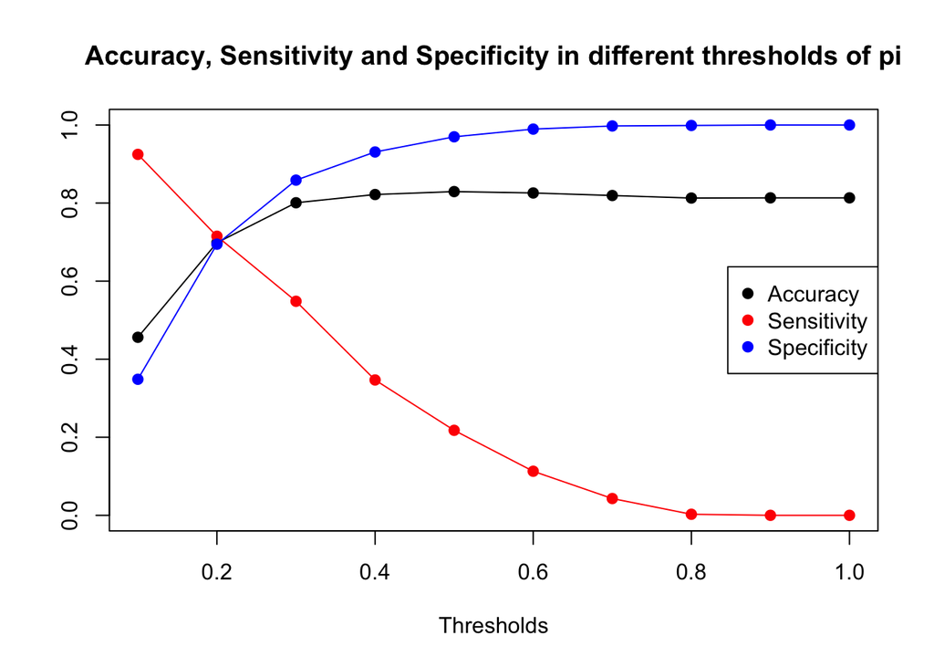

```r
plot(thresholds,acc, type = "o", pch=19, ylim = c(0,1), xlab = "Thresholds", ylab = "", main = "Accuracy, Sensitivity and Specificity in different thresholds of pi")
points(thresholds,sens, type = "o", pch=19, col="red")
points(thresholds,spec, type = "o", pch=19, col="blue")

legend("right",c("Accuracy","Sensitivity","Specificity"),pch=c(19,19,19),col = c("black","red","blue"))
```

### Parsimonious model

```r
###accuracy of prediction for model 2

prediction2 <- predict(model2, test_data,type = "response")
threshold = 0.5
prediction2[prediction2 >= threshold] <- 1
prediction2[prediction2 < threshold] <- 0
confusionMatrix(as.factor(prediction2), test_data$Exited, positive = '1')
```

```
## Confusion Matrix and Statistics
##
##           Reference
## Prediction    0    1
##          0 1571  292
##          1   50   80
##
##                Accuracy : 0.8284
##                  95% CI : (0.8111, 0.8447)
##     No Information Rate : 0.8133
##     P-Value [Acc > NIR] : 0.04384
##
##                   Kappa : 0.2458
##
##  Mcnemar's Test P-Value : < 2e-16
##
##             Sensitivity : 0.21505
##             Specificity : 0.96915
##          Pos Pred Value : 0.61538
##          Neg Pred Value : 0.84326
##              Prevalence : 0.18665
##          Detection Rate : 0.04014
##    Detection Prevalence : 0.06523
##       Balanced Accuracy : 0.59210
##
##        'Positive' Class : 1
##
```

```r
thresholds <- seq(0.1,1,0.1)
acc2 <- rep(0,10)
sens2 <- rep(0,10)
spec2 <- rep(0,10)
for (i in 1:10){
  pred2 <- predict(model2, test_data,type = "response")
  pred2[pred2 >= thresholds[i]] <- 1
  pred2[pred2 < thresholds[i]] <- 0
  c2 <- confusionMatrix(as.factor(pred2), test_data$Exited, positive = '1')
  acc2[i] <- c2$overall['Accuracy']
  sens2[i] <- c2$byClass['Sensitivity']
  spec2[i] <- c2$byClass['Specificity']
}
```

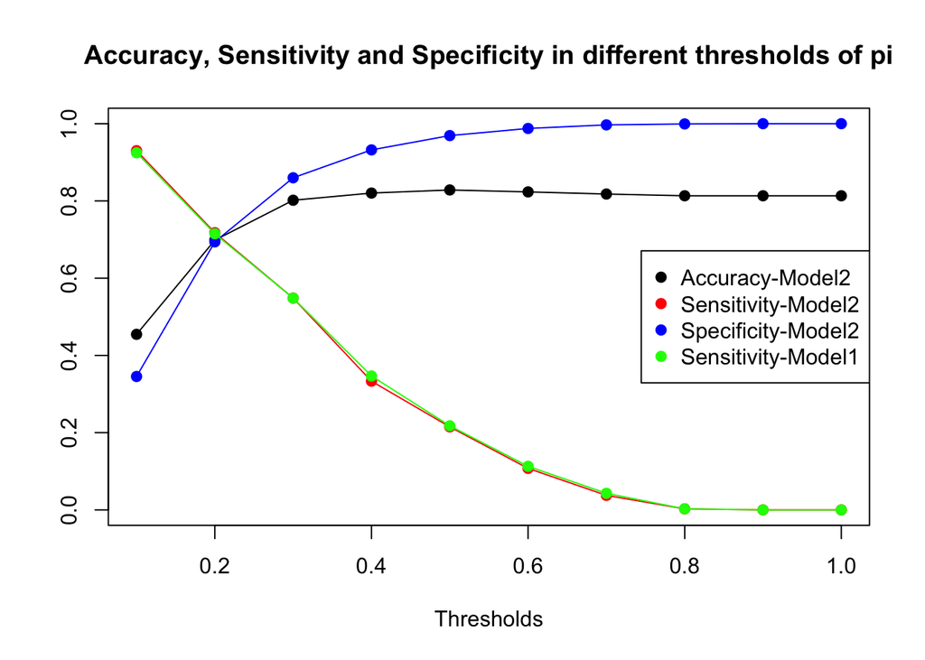

```r
plot(thresholds,acc2, type = "o", pch=19, ylim = c(0,1), xlab = "Thresholds", ylab = "" ,main = "Accuracy, Sensitivity and Specificity in different thresholds of pi")
points(thresholds,sens2, type = "o", pch=19, col="red")
points(thresholds,spec2, type = "o", pch=19, col="blue")
points(thresholds,sens, type = "o", pch=19, col="green")
legend("right",c("Accuracy-Model2","Sensitivity-Model2","Specificity-Model2", "Sensitivity-Model1"),pch=c(19,19,19,19),col = c("black","red","blue","green"))
```

Since sensitivity is important to us, I have also compared with the sensitivity of model 1. Not much difference can be seen.